# (Slide TypeFord GoBike Data Analysis)

## by (Noha Moubarak)

## Introduction

> GoBike is a sharing bicycle system for bicycle riders by Bay Wheels stations and bikes are available throughout San Francisco, the East Bay, and San Jose.

## Univariate Exploration

> In this section, i will start to investigate the main variables and the relation between nomber of rides and them like age,months,gender with user type.

## what is most age use this activity ?

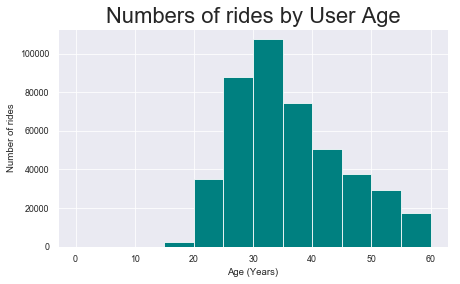

```python
plt.figure(figsize = [7,4])
bin_edges = np.arange(0,df_copy_0_60['age'].max()+1,5)
plt.hist(data = df_copy_0_60, x='age', bins=bin_edges,color = 'teal')
plt.xlabel('Age (Years)')
plt.ylabel('Number of rides')
plt.title('Numbers of rides by User Age', fontsize = 22)
plt.savefig('img01.png');
```

- We can find that the most age users between 30 - 35

## Which months the riders prefere to do this activity?

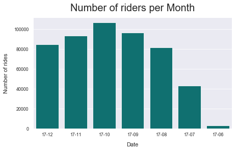

```python
plt.figure(figsize = [7,4])
sns.countplot(data = df_copy, x = 'start_time_month', color = 'teal')
plt.title("Number of riders per Month", fontsize=20, y=1.03)
plt.xlabel("Date", fontsize=11, labelpad=10)
plt.ylabel("Number of rides", fontsize=11, labelpad=10)
plt.savefig('img03.png');
```

- from the above chart months distribution we can find that the most month have alot of ride is October may be because of weather

## What is the most day in week the rider prefere to do this activity?

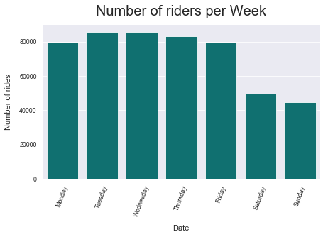

```python
plt.figure(figsize = [7,4])
sns.countplot(data = df_copy, x = 'start_time_week', color = 'teal')
plt.title("Number of riders per Week", fontsize=20, y=1.03)
plt.xlabel("Date", fontsize=11, labelpad=10)
plt.ylabel("Number of rides", fontsize=11, labelpad=10)
plt.xticks(np.arange(0,7,1),['Monday','Tuesday','Wednesday','Thursday','Friday','Saturday','Sunday'], rotation = 70)
plt.savefig('img04.png');
```

- from the above plot we can say that riders prefere to do this activity during weekdays than weekends

## What is the most user type do this activity?

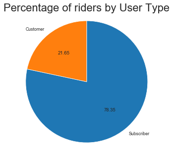

```python
plt.figure(figsize = [8,5])
sorted_counts =df_copy['user_type'].value_counts()
plt.pie(sorted_counts, labels = sorted_counts.index, startangle = 90,
        counterclock = False, autopct = '%.2f')
plt.axis('square')
plt.title('Percentage of riders by User Type', fontsize = 22)
plt.savefig('img05.png');
```

- My observation from the previous chart is the subscribers percentage is more than 75% and the rset for customers

## Bivariate Exploration

> In this section, investigate relationships between pairs of variables shown above like month and gender with months

## What is the most gender use this activity in each month?

[figure not shown]

```python
plt.figure(figsize = [8,4])
sb.countplot(data = df_copy, x = 'start_time_month',hue = 'member_gender')
plt.xlabel('Month')
plt.ylabel('Bike Ride Count')
plt.title('Number of rides by user gender per month', fontsize = 22)
plt.xticks(np.arange(0,6,1),['January','February','March','April','May','June','July','August','September','October','November','December'], rotation = 70)
plt.savefig('img06.png');
```

- After adding gender to the onths we found that number of rides by male is more than female in every month